# Stochastic PQRUT

This R package implements the Stochastic PQRUT model, which performs flood frequency analysis.The model simulates Precipitation, temperature and initial conditions and uses the deterministic rainfall-runoff model PQRUT to obtain the final discharge values. The return periods are estimated using plotting positions. The analysis is performed using seasonal values but currently the seasonal split is hard coded to season 1= “9-11”,season 2=“12-2”,season 3=“3-5”,season 4=“6-8”.

1. Load the library,set seed and define number of simulations

```r
library(StochasticPQRUT)
set.seed(567)
  Nsim=10000
```

2. Find critical duration - the duration of the storm event that results in maximum discharge. For this Precipitation and Discharge with daily timestep are used. Sample data for Hørte (stN 16.193) is included in this package.

```r
  data(Qd);data(P)
   head(Qd); head(P)
```

```
##         date  Q
## 1 1961-01-01 NA
## 2 1961-01-02 NA
## 3 1961-01-03 NA
## 4 1961-01-04 NA
## 5 1961-01-05 NA
## 6 1961-01-06 NA
```

```
##         date    Pr
## 1 1961-09-01  0.00
## 2 1961-09-02  0.00
## 3 1961-09-03  0.00
## 4 1961-09-04  0.00
## 5 1961-09-05  0.00
## 6 1961-09-06 42.15
```

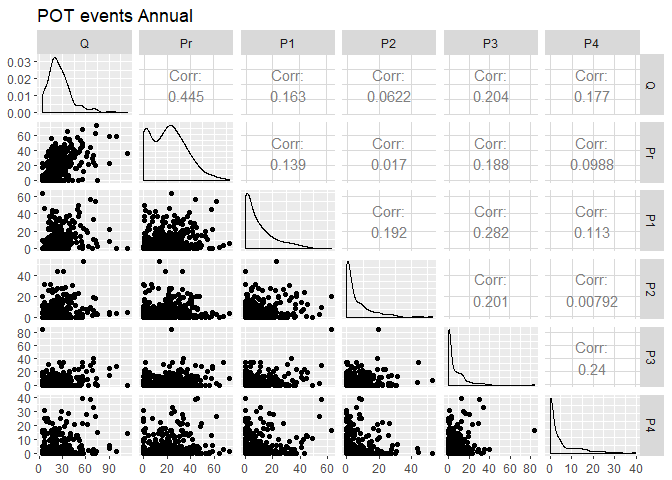

```r
a=criticalduration(Q=Qd,P=P,qtT=0.9,PDFplots=FALSE,intEvent=7,writeResults=FALSE)
```

The function returns a list, containing the critical duration and dataframes of the extracted POT.

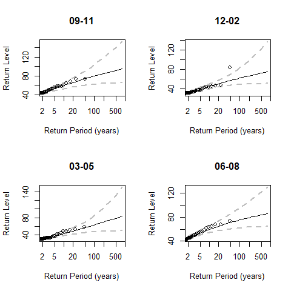

```r
d=rainPOT(datarainfall=P,pathmain,durt=24,qFtset=0.98,qWtset=0.99,qSptset=0.99,qStset=0.98,distfunc="GP",
          writeResults=FALSE,PDFplots=FALSE)
```

```r
  data(sl);data(SWE);data(Td)
   head(sl); head(SWE); head(Td)
```

```
##         date    sl
## 1 1999-09-01 31.57
## 2 1999-09-02 30.24
## 3 1999-09-03 31.64
## 4 1999-09-04 32.86
## 5 1999-09-05 33.23
## 6 1999-09-06 33.42
```

```
##         date SWE
## 1 1999-09-01   0
## 2 1999-09-02   0
## 3 1999-09-03   0
## 4 1999-09-04   0
## 5 1999-09-05   0
## 6 1999-09-06   0
```

```
##         date     Td
## 1 1999-09-01  8.743
## 2 1999-09-02 10.268
## 3 1999-09-03 14.592
## 4 1999-09-04 15.059
## 5 1999-09-05 14.923
## 6 1999-09-06 15.149
```

The function returns a list of initial conditions for the given seasons.

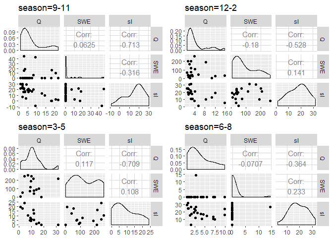

```r
b=initcond(Qobs=Qd,sl=sl,
           POTF=a$POTF,POTW=a$POTW,POTSp=a$POTSp,POTS=a$POTS,SWE=SWE,Td=Td,durt=a$d,PDFplots=FALSE,writeResults=FALSE)
```

5.Extract hyetographs for flood events. This function matches the dates for the POT events, extracted in step 3 to hourly precipitation dataset. It is assumed that the daily data is recorded at 6 am.

```r
#load data data(p1)
head(p1)
```

```
##         date     time p
## 1 01/01/1979 00:00:00 0
## 2 01/01/1979 01:00:00 0
## 3 01/01/1979 02:00:00 0
## 4 01/01/1979 03:00:00 0
## 5 01/01/1979 04:00:00 0
## 6 01/01/1979 05:00:00 0
```

```r
h=stormp(prpFt=d$pF,prpWt=d$PW,prpSpt=d$PSp,prpSt=d$PS,p1 = p1,durt=24,writeResults=FALSE,PDFplots=FALSE)
```

6. Extract temperature sequence. Similarly to 4, the function matches the dates of the POT events to hourly Temperature data

```r
#load data
data(h1)
head(h1)
```

```
##         date     time         T
## 1 01/01/1979 00:00:00 -23.38190
## 2 01/01/1979 01:00:00 -23.48557
## 3 01/01/1979 02:00:00 -23.58923
## 4 01/01/1979 03:00:00 -23.69290
## 5 01/01/1979 04:00:00 -23.83850
## 6 01/01/1979 05:00:00 -23.98410
```

```r
#error due to NULL values in sequence
h1=temprsim(incondFt=b$ntp1F,incondWt=b$ntp1W,incondSpt=b$ntp1Sp,incondSt=b$ntp1S,durt=24,tm=h1,writeResults=FALSE,PDFplots=FALSE)
```

7. Simulate initial conditions. The values are simulated using truncated multivariate normal distribution. This ensures that the simulated values are within the limits of the observed series.

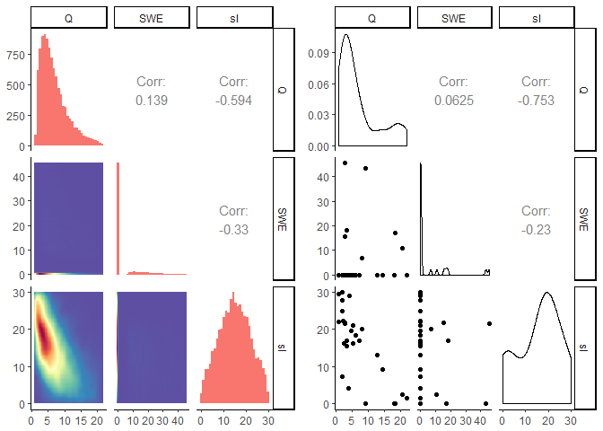

```r
layout(matrix(1:4, nrow=2))
gincon=initconditions(incondFt=b$ntp1F,incondWt=b$ntp1W,incondSpt=b$ntp1Sp,incondSt=b$ntp1S, Nsim=Nsim,durt=a$d,writeResults=FALSE,PDFplots=FALSE)
#plot for season "09-11"
print(gincon$plot1)
```

```r
 h=simulateP(Nsim=Nsim,durt=24,distfunc="GP",hyet=h,TempSeq=h1,Pexp=d$par,writeResults=FALSE,PDFplots=FALSE)
```

```
## [1] "Ft"
## [1] "Wt"
## [1] "Spt"
## [1] "St"
```

9.Calibrate the hydrological model PQRUT for selected events. In this case optim is used , however a better option is to use ppso package.

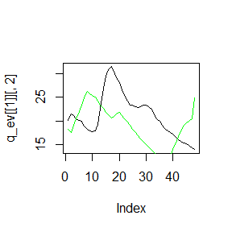

```r
library(hydroGOF)
#Prepare data
b1=b[[1]]
p1$date=as.Date(p1$date,format="%d/%m/%Y")
b2=match(as.character(b1$date+1),as.character(p1$date))
data(h1)
#extract Precipitation and temperature values
p_ev=lapply(1:length(b2), function(x) p1[(b2[x]-42):(b2[x]+5),] )

b3=match(as.character(b1$date+1),as.character(as.Date(Qh$Date)))
q_ev=lapply(1:length(b2), function(x) Qh[(b3[x]-42):(b3[x]+5),] )
h1$date=as.Date(h1$date,format="%d/%m/%Y")
b4=match(as.character(b1$date+1),as.character(as.Date(h1$date)))
t_ev=lapply(1:length(b2), function(x) h1[(b4[x]-42):(b4[x]+5),] )
PT_ev=lapply(1:length(b2), function(x) cbind(p_ev[[x]][3],t_ev[[x]][3]))
#
bn=data.frame(b1[17,2:4])

#then take the medium of all values
  #in this case the model performance is poor
fn1=function(par,...){
qsim=PQRUT(int1=bn,tm1 = PT_ev[[17]],kd=3,durt =48,param.station =c(0.1,0.04,25),Area1 = 157, snpSpt=0.3,ttsnow=-3,Tmax=0.5,Tmin=0.5 )
KGE1=-KGE(qsim[[1]],q_ev[[17]][,2])

return(KGE1)
}
par1=optim(par = c(0.1,0.04,25),fn = fn1,method = "L-BFGS-B",lower=c(0.01,0.01,1),upper = c(0.5,0.5,100))
#
#
qsim=PQRUT(int1=bn,tm1 = PT_ev[[17]],kd=3,durt =48,param.station =par1$par,Area1 = 157, snpSpt=0.3,ttsnow=-3,Tmax=0.5,Tmin=0.5)
plot(q_ev[[1]][,2],type="l")
points(qsim[[1]],type="l",col="green")
```

10. Simulate discharge values. The model PQRUT is used to simulate discharge values. The model was calibrated using method described in Filipova 2016.

```r
gFT= hydrolsim(seasn="Ft",ncl=2,param.station=c(0.1138291,0.028429,19.85680),Nsim=Nsim,int1=gincon$SWEFt,Pt=as.matrix(h[[1]]),E=h[[5]],durt=24,Area1=157,kd=2.8,snpSpt=0.3,ttsnow=-1,Tmax=0.5,Tmin=0.5,writeResults=FALSE,PDFplots=FALSE)
gWT= hydrolsim(seasn="Ft",ncl=2,param.station=c(0.1138291,0.028429,19.85680),Nsim=Nsim,int1=gincon$SWEFt,Pt=as.matrix(h[[2]]),E=h[[6]],durt=24,Area1=157,kd=2.8,snpSpt=0.3,ttsnow=-1,Tmax=0.5,Tmin=0.5,writeResults=FALSE,PDFplots=FALSE)
gSpT= hydrolsim(seasn="Ft",ncl=2,param.station=c(0.1138291,0.028429,19.85680),Nsim=Nsim,int1=gincon$SWEFt,Pt=as.matrix(h[[3]]),E=h[[7]],durt=24,Area1=157,kd=2.8,snpSpt=0.3,ttsnow=-1,Tmax=0.5,Tmin=0.5,writeResults=FALSE,PDFplots=FALSE)
gST= hydrolsim(seasn="Ft",ncl=2,param.station=c(0.1138291,0.028429,19.85680),Nsim=Nsim,int1=gincon$SWEFt,Pt=as.matrix(h[[4]]),E=h[[8]],durt=24,Area1=157,kd=2.8,snpSpt=0.3,ttsnow=-1,Tmax=0.5,Tmin=0.5,writeResults=FALSE,PDFplots=FALSE)
```

11. Calculate the return levels. This function uses plotting positions to estimate the return periods and returns a list of return levels.

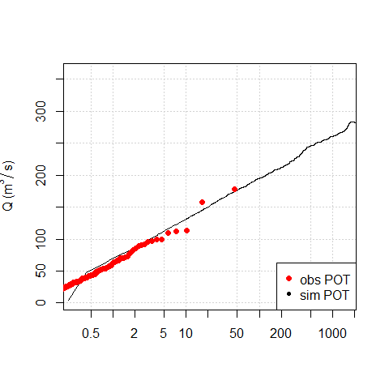

```r
gsim=list(Ft=gFT,Wt=gWT,Spt=gSpT,St=gST)
  d1=d[2:5]
  m1=annualfreqplot(qtT=0.9,Nsim=Nsim,durt=24,qobs=Qh,Pint=h[10:13],incond=gincon,nsy=d1,Qsim=gsim,writeResults=FALSE,PDFplots=FALSE)
```